# Data Science Task

Ishwinder Kaur

May 1, 2020

# 1 Introduction

This R markdown demonstrates predictive analysis for time series data. For this analysis we use the **Bowel Cancer Screening dataset.**

```r
#loading the relevant libraries
library(tidyverse)
#library(ts)
library(ggplot2)
library(forecast)

options(scipen = 999)

kLightBlue = "#00AAE5"
kDarkBlue = "#005AAD"
kPurple = "#A33299"
```

# 2 About the dataset

This dataset is taken from the data provided as part of the **National Bowel Cancer Screening Program**. The data consists of number of screening kits returned, by sex and quarter, people aged 50–74, 1 Jan–31 Mar 2014 to 1 Apr–30 Jun 2019.

Link: https://www.aihw.gov.au/reports/cancer-screening/national-cancer-screening-programs-participation/data

For the purpose of this analysis, we will use the total number of persons.

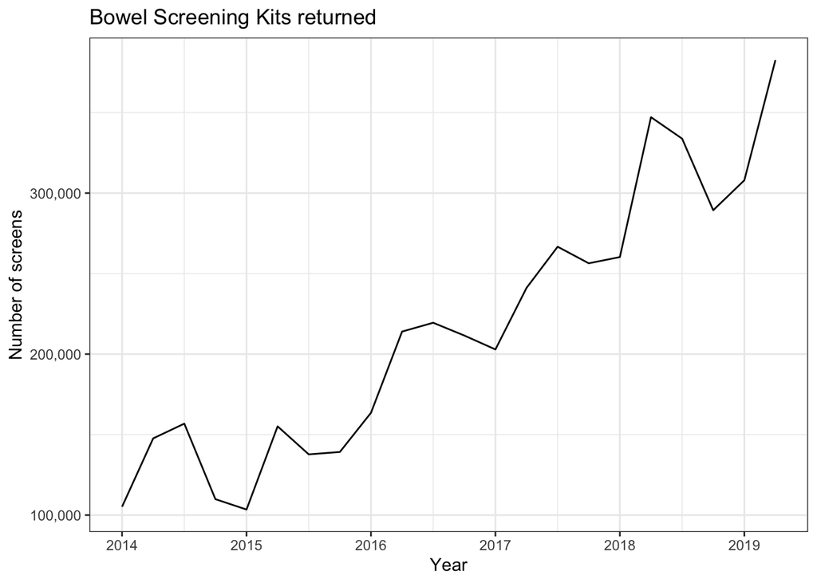

```r
# about the dataset:

bowel = readxl::read_xlsx('bowel screening data.xlsx')

# converting bowel screen dataset into a timeseries
bowel_ts <- ts(bowel[,'Persons'], start=2014, frequency=4)

# plotting the time series
autoplot(bowel_ts) +
  ggtitle("Bowel Screening Kits returned") +
  xlab("Year") +
  ylab("Number of screens") +
  scale_y_continuous(labels = scales::comma) +
  theme_minimal() +
  theme_bw()
```

# 3 Main model and forecasts

The first model is a linear model.

Below is the summary of the model:

```r
fit.cancer <- tslm(bowel_ts ~ trend + season)
summary(fit.cancer)
```

```
##
## Call:
## tslm(formula = bowel_ts ~ trend + season)
##
## Residuals:
##    Min     1Q Median     3Q    Max
## -37726 -11096  -2379  14572  33284
##
## Coefficients:
##             Estimate Std. Error t value         Pr(>|t|)
## (Intercept)  60047.2    11477.5   5.232 0.00006767204833 ***
## trend        11863.7      701.5  16.911 0.00000000000455 ***
## season2      45527.3    12035.6   3.783          0.00149 **
## season3      32351.4    12601.6   2.567          0.01999 *
## season4      -1140.5    12621.1  -0.090          0.92905
## ---
## Signif. codes:  0 '***' 0.001 '**' 0.01 '*' 0.05 '.' 0.1 ' ' 1
##
## Residual standard error: 20810 on 17 degrees of freedom
## Multiple R-squared:  0.9484, Adjusted R-squared:  0.9362
## F-statistic: 78.04 on 4 and 17 DF,  p-value: 0.0000000001043
```

## 3.1 Plot of the actual and fitted values

Below is a plot of the actual versus fitted values.

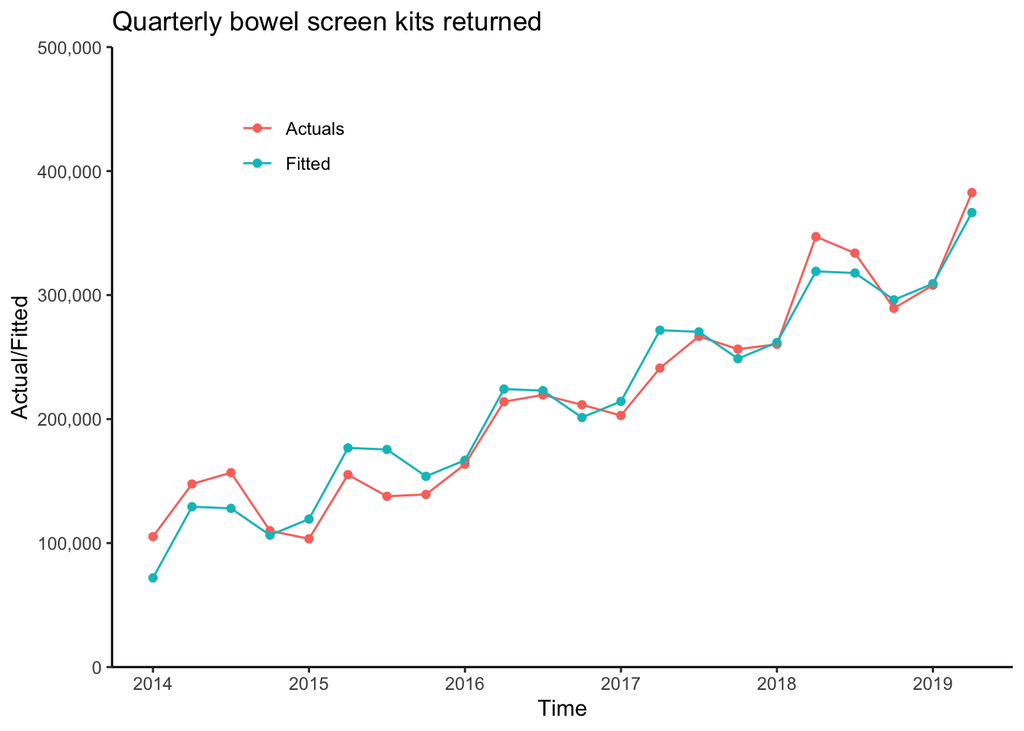

```r
cbind(Time = time(bowel_ts), Actuals=bowel_ts, Fitted=fitted(fit.cancer)) %>%
  as.data.frame() %>%
  gather(key = 'Type', value = 'value', -Time) %>%
  ggplot(aes(x = Time,
             y = value,
             colour = as.factor(Type) )) +
  ggtitle("Bowel Screening Kits returned/forecasts") +
  geom_point() +
  geom_line() +
  ylab("Actual/Fitted") + xlab("Time") +
  ggtitle("Quarterly bowel screen kits returned") +
  theme_bw() +
  theme_classic() +
  theme(
    legend.title = element_blank(),
    legend.position = c(0.2, 0.85)
  ) +
  scale_y_continuous(limits = c(0,500000), expand = c(0,0), labels = scales::comma)
```

```r
#  scale_colour_brewer(palette="Dark2", name="Quarter") +
#  geom_abline(intercept=0, slope=1)
```

## 3.2 Forecasts

Following are the forecasts for the model created above for the 10 quarters starting from 2019 Q3 to 2021 Q4.

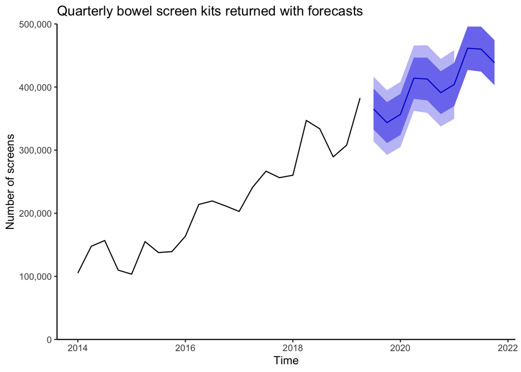

```r
fcast <- forecast(fit.cancer)
autoplot(fcast) +
  ggtitle("Forecasts of bowel screens") +
  xlab("Time") + ylab("Number of screens") +
  ggtitle("Quarterly bowel screen kits returned with forecasts") +
  theme_bw() +
  theme_classic() +
  scale_y_continuous(limits = c(0,500000), expand = c(0,0), labels = scales::comma)
```

## 3.3 Accuracy

Accuracy of the main model is as follows:

```r
accuracy(fcast)
```

```
##                                ME     RMSE      MAE        MPE    MAPE
## Training set 0.000000000002646045 18293.77 14725.44 -0.3640826 8.59605
##                   MASE      ACF1
## Training set 0.3171061 0.4846364
```

# 4 Other models

## 4.1 Alternative model 1

Alternative Model 1: Exponential smoothing

```r
fc1 = ses(bowel_ts, h = 4)
round(accuracy(fc1),2)
```

```
##                    ME     RMSE      MAE MPE  MAPE MASE  ACF1
## Training set 12613.79 35847.25 26741.87 4.3 12.75 0.58 -0.06
```

## 4.2 Alternative model 2

Alternative Model 2: Forecasting with Holt’s Method

```r
fc2 = holt(bowel_ts, h = 2)
round(accuracy(fc2),2)
```

```
##                  ME    RMSE      MAE   MPE  MAPE MASE ACF1
## Training set 861.38 29867.7 24411.27 -3.37 13.09 0.53 0.17
```

In comparison to the alternative models, the first model still has higher accuracy and lower RMSE.